# Replication of “Community-Based Fact-Checking on Twitter’s Birdwatch Platform”

Sara Bleier, Srijana Shrestha

06/20/2025

> **Note:** Considering this paper was published in 2021, it seems there have been changes in the data. We have followed the same methodology and seen roughly similiar results to the original paper, albeit with some differences in quantity.

```r
notes <- read_tsv("filtered_data/filtered_notes.tsv")
ratings <- read_tsv("filtered_data/complete_filtered_ratings.tsv")
```

## Figure 2

Replication: Number of users who responded “Yes” to the question “Did you link to sources you believe most people would consider trustworthy?”

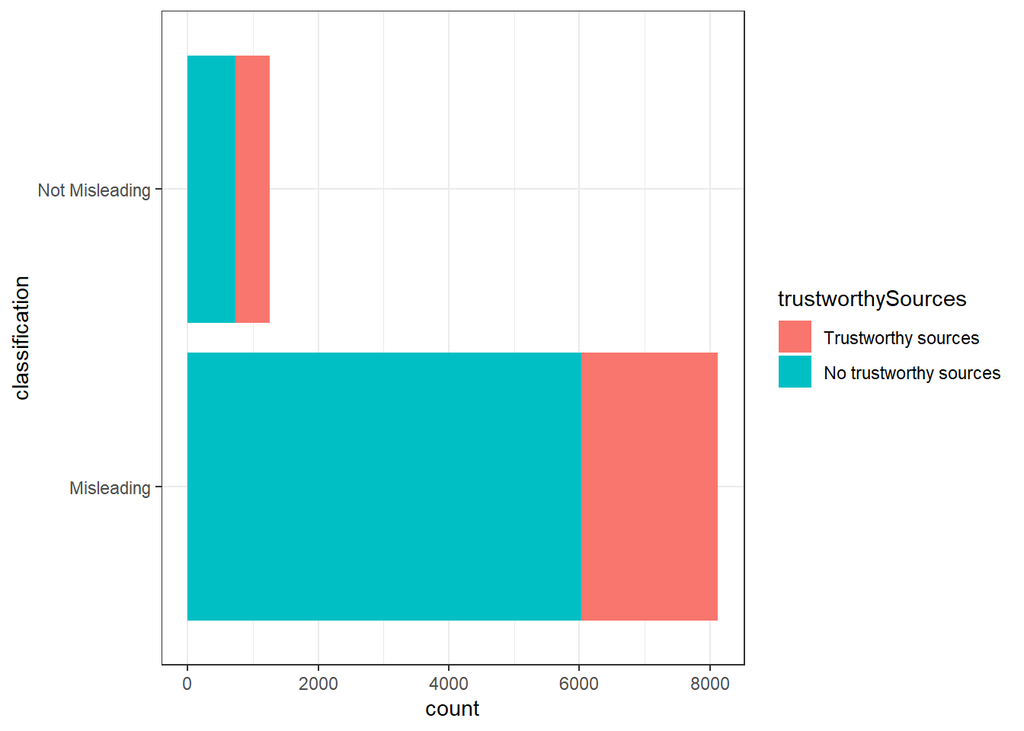

```r
notes$trustworthySources <- factor(notes$trustworthySources, levels = c(0, 1), labels = c("Trustworthy sources", "No trustworthy sources"))

ggplot(notes, aes(x = classification, fill = trustworthySources)) +
    geom_bar() +
    scale_x_discrete(labels = c(
        "MISINFORMED_OR_POTENTIALLY_MISLEADING" = "Misleading",
        "NOT_MISLEADING" = "Not Misleading"
    )) +
    coord_flip()
```

### Figure 2 Report:

When replicating the figure, we get a higher count, considering the difference data, as noted previously

## Figure 3

Replication: Number of Birdwatch notes per checkbox answer option in response to the question “Why do you believe this tweet may be misleading?”

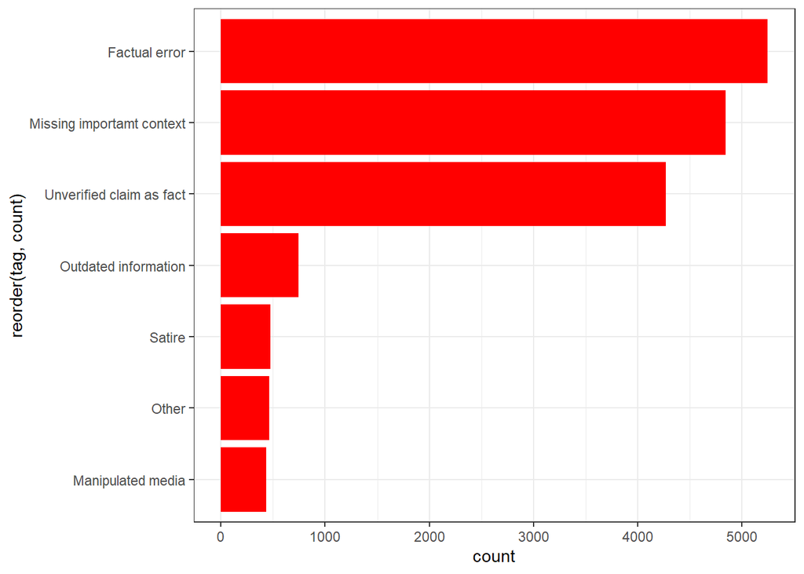

```r
misleading_counts <- notes %>%
    summarise(
        misleadingOther = sum(misleadingOther),
        misleadingOutdatedInformation = sum(misleadingOutdatedInformation),
        misleadingFactualError = sum(misleadingFactualError),
        misleadingManipulatedMedia = sum(misleadingManipulatedMedia),
        misleadingMissingImportantContext = sum(misleadingMissingImportantContext),
        misleadingUnverifiedClaimAsFact = sum(misleadingUnverifiedClaimAsFact),
        misleadingSatire = sum(misleadingSatire)
    ) %>%
    pivot_longer(everything(), names_to = "tag", values_to = "count") %>%
    arrange(desc(count))

ggplot(misleading_counts, aes(x = reorder(tag, count), y = count)) +
    geom_bar(stat = "identity", fill = "red") +
    coord_flip() +
    scale_x_discrete(labels = c(
        "misleadingOther" = "Other",
        "misleadingOutdatedInformation" = "Outdated information",
        "misleadingFactualError" = "Factual error",
        "misleadingManipulatedMedia" = "Manipulated media",
        "misleadingMissingImportantContext" = "Missing importamt context",
        "misleadingUnverifiedClaimAsFact" = "Unverified claim as fact",
        "misleadingSatire" = "Satire"
    ))
```

### Figure 3 Report:

Again, considering differences in data, we found slightly different results, but the conclusions remain consistent.

## Figure 4:

Number of Birdwatch notes per checkbox answer option in response to the question “Why do you believe this tweet is not misleading?”

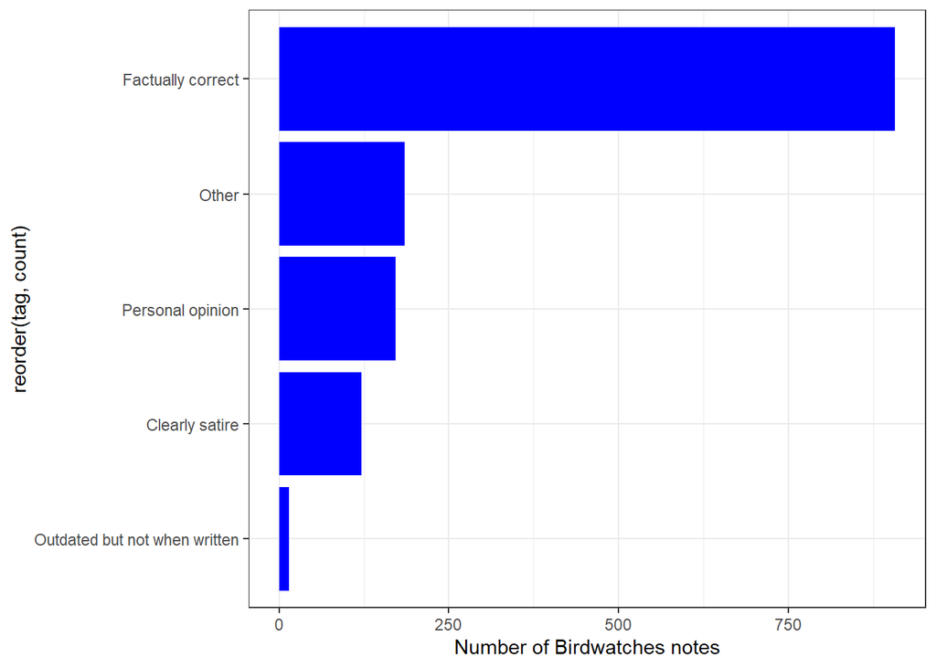

```r
misleading_counts <- notes %>%
    summarise(
        notMisleadingPersonalOpinion = sum(notMisleadingPersonalOpinion),
        notMisleadingOther = sum(notMisleadingOther),
        notMisleadingClearlySatire = sum(notMisleadingClearlySatire),
        notMisleadingFactuallyCorrect = sum(notMisleadingFactuallyCorrect),
        notMisleadingOutdatedButNotWhenWritten = sum(notMisleadingOutdatedButNotWhenWritten),
    ) %>%
    pivot_longer(everything(), names_to = "tag", values_to = "count") %>%
    arrange(desc(count))

ggplot(misleading_counts, aes(x = reorder(tag, count), y = count)) +
    geom_bar(stat = "identity", fill = "blue") +
    coord_flip() +
    labs(y = "Number of Birdwatches notes") +
    scale_x_discrete(labels = c(
        "notMisleadingOther" = "Other",
        "notMisleadingOutdatedButNotWhenWritten" = "Outdated but not when written",
        "notMisleadingPersonalOpinion" = "Personal opinion",
        "notMisleadingFactuallyCorrect" = "Factually correct",
        "notMisleadingClearlySatire" = "Clearly satire"
    ))
```

### Figure 4 Report:

Again, considering differences in data, we found slightly higher results, but the conclusions remain consistent.

## Figure 8:

Number of ratings per checkbox answer option in response to the prompt “What about this note was helpful to you?”

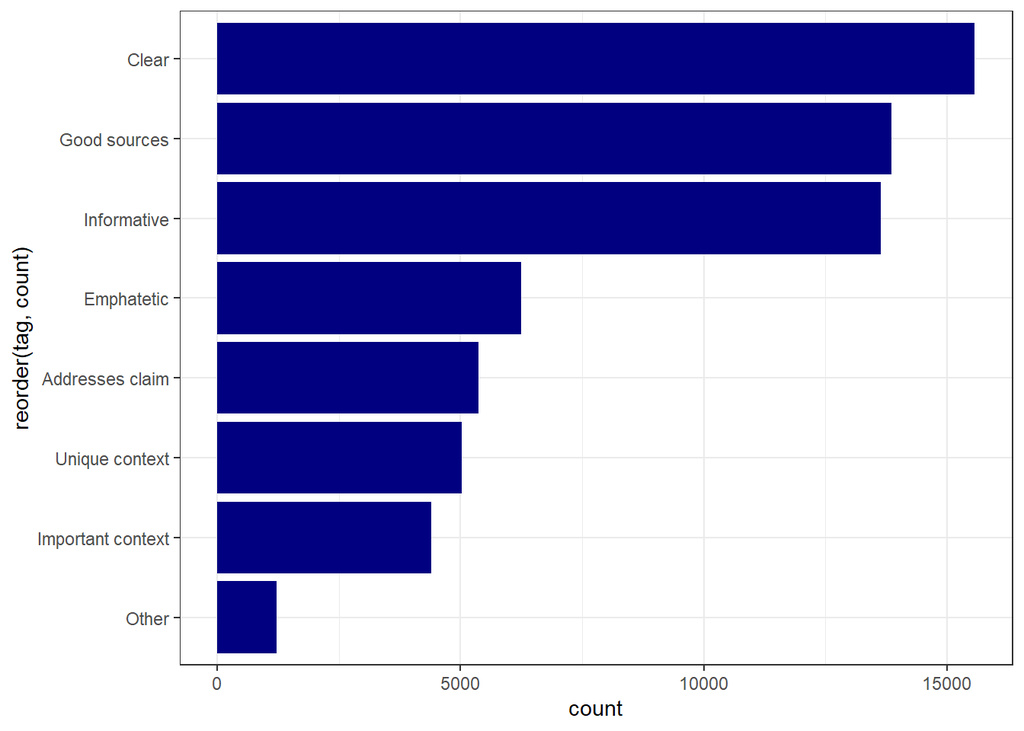

```r
helpful_ratings_counts <- ratings %>%
    summarise(
        helpfulInformative = sum(helpfulInformative),
        helpfulClear = sum(helpfulClear),
        helpfulGoodSources = sum(helpfulGoodSources),
        helpfulEmpathetic = sum(helpfulEmpathetic),
        helpfulUniqueContext = sum(helpfulUniqueContext),
        helpfulAddressesClaim = sum(helpfulAddressesClaim),
        helpfulImportantContext = sum(helpfulImportantContext),
        helpfulOther = sum(helpfulOther)
    ) %>%
    pivot_longer(everything(), names_to = "tag", values_to = "count") %>%
    arrange(desc(count))

ggplot(helpful_ratings_counts, aes(x = reorder(tag, count), y = count)) +
    geom_bar(stat = "identity", fill = "navyblue") +
    coord_flip() +
    scale_x_discrete(labels = c(
        "helpfulInformative" = "Informative",
        "helpfulClear" = "Clear",
        "helpfulGoodSources" = "Good sources",
        "helpfulEmpathetic" = "Emphatetic",
        "helpfulUniqueContext" = "Unique context",
        "helpfulAddressesClaim" = "Addresses claim",
        "helpfulImportantContext" = "Important context",
        "helpfulOther" = "Other"
    ))
```

### Figure 8 Report:

We do find that less notes are rated informative in our data, as compared to the original paper

## Figure 9:

Number of ratings per checkbox answer option in response to the question “Help us understand why this note was unhelpful.”

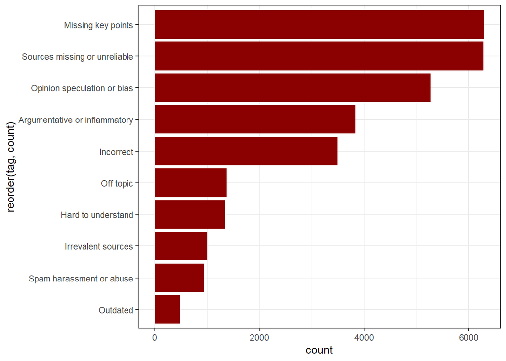

```r
unhelpful_ratings_counts <- ratings %>%
    summarise(
        notHelpfulSourcesMissingOrUnreliable = sum(notHelpfulSourcesMissingOrUnreliable),
        notHelpfulOpinionSpeculationOrBias = sum(notHelpfulOpinionSpeculationOrBias),
        notHelpfulMissingKeyPoints = sum(notHelpfulMissingKeyPoints),
        notHelpfulArgumentativeOrBiased = sum(notHelpfulArgumentativeOrBiased),
        notHelpfulIncorrect = sum(notHelpfulIncorrect),
        notHelpfulOffTopic = sum(notHelpfulOffTopic),
        notHelpfulHardToUnderstand = sum(notHelpfulHardToUnderstand),
        notHelpfulSpamHarassmentOrAbuse = sum(notHelpfulSpamHarassmentOrAbuse),
        notHelpfulOutdated = sum(notHelpfulOutdated),
        notHelpfulIrrelevantSources = sum(notHelpfulIrrelevantSources)
    ) %>%
    pivot_longer(everything(), names_to = "tag", values_to = "count") %>%
    arrange(desc(count))

ggplot(unhelpful_ratings_counts, aes(x = reorder(tag, count), y = count)) +
    geom_bar(stat = "identity", fill = "dark red") +
    coord_flip() +
    scale_x_discrete(labels = c(
        notHelpfulSourcesMissingOrUnreliable = ("Sources missing or unreliable"),
        notHelpfulOpinionSpeculationOrBias = ("Opinion speculation or bias"),
        notHelpfulMissingKeyPoints = ("Missing key points"),
        notHelpfulArgumentativeOrBiased = ("Argumentative or inflammatory"),
        notHelpfulIncorrect = ("Incorrect"),
        notHelpfulOffTopic = ("Off topic"),
        notHelpfulHardToUnderstand = ("Hard to understand"),
        notHelpfulSpamHarassmentOrAbuse = ("Spam harassment or abuse"),
        notHelpfulOutdated = ("Outdated"),
        notHelpfulIrrelevantSources = ("Irrevalent sources")
    ))
```

### Figure 9 Report:

We found roughly similar results, with slight differences in quantity

## Figure 5c:

CCDF for word count in text explanations of Birdwatch notes.

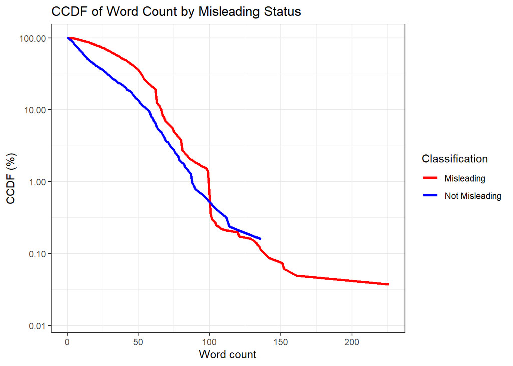

```r
notes <- mutate(notes, word_count = str_count(summary, "\\w+"))

notes <- arrange(notes, word_count)
count_of_distinct <- group_by(notes, classification, word_count) |>
    summarize(count = n()) |>
    group_by(classification) |>
    arrange(classification, word_count) |>
    mutate(notes_with_count = rev(cumsum(rev(count))), total_notes = sum(count), percent = (notes_with_count / total_notes) * 100)

ggplot(count_of_distinct, aes(x = word_count, y = percent, color = classification)) +
    geom_line(size = 1.2) +
    scale_y_log10(labels = scales::comma) +
    scale_color_manual(
        values = c(
            "MISINFORMED_OR_POTENTIALLY_MISLEADING" = "red",
            "NOT_MISLEADING" = "blue"
        ),
        labels = c(
            "MISINFORMED_OR_POTENTIALLY_MISLEADING" = "Misleading",
            "NOT_MISLEADING" = "Not Misleading"
        )
    ) +
    labs(
        x = "Word count",
        y = "CCDF (%)",
        title = "CCDF of Word Count by Misleading Status",
        color = "Classification"
    )
```

### Figure 5c Report:

Besides the quantiative difference due to data difference, we also note that the not misleading notes actually overtake the misleading notes in word count briefly before being cut off, unlike in the paper

## Figure 7a:

CCDF for helpfulness ratio

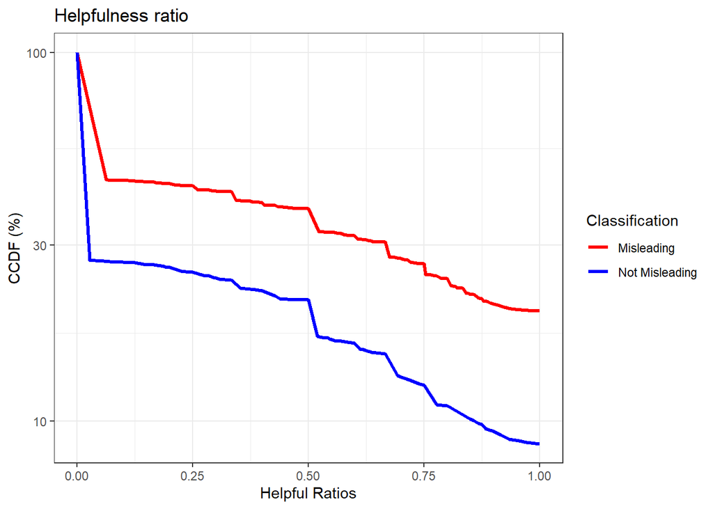

```r
ratings <- group_by(ratings, noteId) |> mutate(votecount = n())

notes$votecount <- ratings$votecount[match(notes$noteId, ratings$noteId)]
# we assumed NA = 0 bc it won't have any row from the ratings table
notes$votecount[is.na(notes$votecount)] <- 0
ratings <- group_by(ratings, noteId) |> mutate(helpful_ratio = sum(helpful) / votecount)

notes$helpful_ratio <- ratings$helpful_ratio[match(notes$noteId, ratings$noteId)]
# we assumed NA = 0 bc it won't have any row from the ratings table
notes$helpful_ratio[is.na(notes$helpful_ratio)] <- 0

helpful_ratio <- group_by(notes, classification, helpful_ratio) |>
    summarize(count = n()) |>
    group_by(classification) |>
    arrange(classification, helpful_ratio) |>
    mutate(helpful = rev(cumsum(rev(count))), total_notes = sum(count), percent = (helpful / total_notes) * 100)

ggplot(helpful_ratio, aes(x = helpful_ratio, y = percent, color = classification)) +
    geom_line(size = 1.2) +
    scale_y_log10() +
    scale_color_manual(
        values = c(
            "MISINFORMED_OR_POTENTIALLY_MISLEADING" = "red",
            "NOT_MISLEADING" = "blue"
        ),
        labels = c(
            "MISINFORMED_OR_POTENTIALLY_MISLEADING" = "Misleading",
            "NOT_MISLEADING" = "Not Misleading"
        )
    ) +
    labs(
        x = "Helpful Ratios",
        y = "CCDF (%)",
        title = "Helpfulness ratio",
        color = "Classification"
    )
```

### Figure 7a Report:

This is the first figure where we do see significance differences, as the notes rated not misleading are considered significantly less helpful then in the original paper

## Figure 7b:

CCDF for total votes

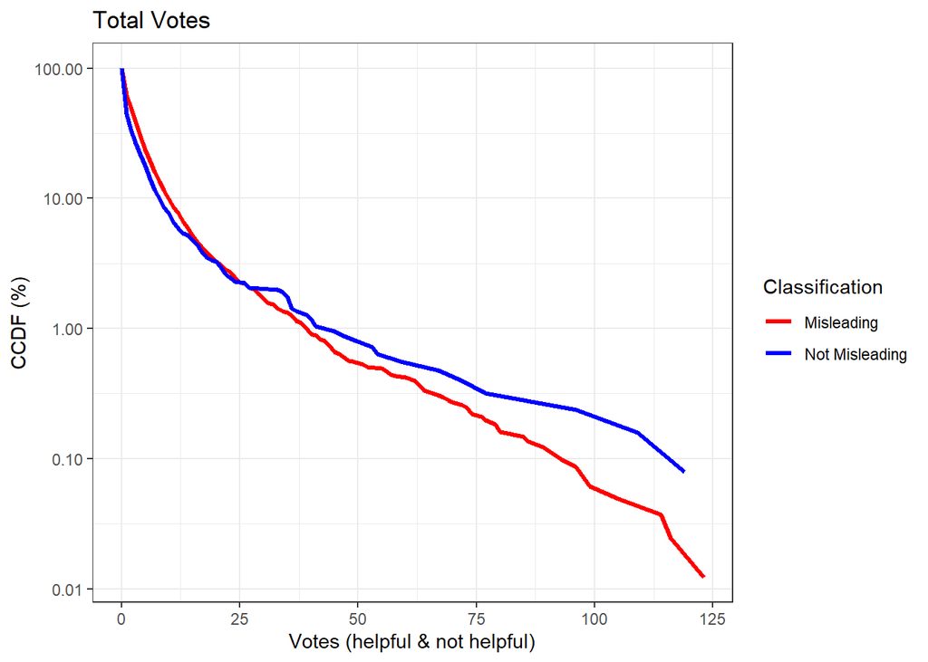

```r
count_of_votes <- group_by(notes, classification, votecount) |>
    summarize(count = n()) |>
    group_by(classification) |>
    arrange(classification, votecount) |>
    mutate(votes = rev(cumsum(rev(count))), total_notes = sum(count), percent = (votes / total_notes) * 100)
ggplot(count_of_votes, aes(x = votecount, y = percent, color = classification)) +
    geom_line(size = 1.2) +
    scale_y_log10(labels = scales::comma) +
    scale_color_manual(
        values = c(
            "MISINFORMED_OR_POTENTIALLY_MISLEADING" = "red",
            "NOT_MISLEADING" = "blue"
        ),
        labels = c(
            "MISINFORMED_OR_POTENTIALLY_MISLEADING" = "Misleading",
            "NOT_MISLEADING" = "Not Misleading"
        )
    ) +
    labs(
        x = "Votes (helpful & not helpful)",
        y = "CCDF (%)",
        title = "Total Votes",
        color = "Classification"
    )
```

### Figure 7b Report:

We’ve found similiar results, but the highest vote count is only 123, as compared to ~150 in the original paper

```r
# donwloaded file in browser bc didn't work to curl here (downloaded as empty)
load(file.path("C:/Users/ds3/Downloads/source_tweets.Rdata"), ournew_env <- new.env())
source_tweets <- ournew_env[["."]]
```

## Figure 10:

Regression results for helpfulness ratio and total votes as dependent variables (DV). Reported are standardized parameter estimates and 99 % confidence intervals.

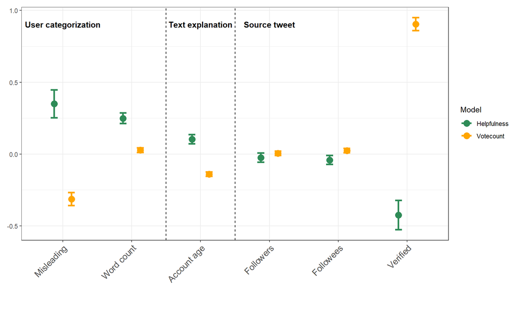

```r
# join data
notes_with_ratings <- inner_join(notes, ratings, by = c("noteId", "votecount"))
notes_ratings_source <- inner_join(notes_with_ratings, source_tweets, by = c("noteId", "tweetId"))

# reformat helpful
notes_ratings_source <- mutate(notes_ratings_source,
    helpful = if_else(!is.na(helpfulnessLevel) &
        helpfulnessLevel %in% c("HELPFUL", "SOMEWHAT_HELPFUL"), 1, helpful),
    notHelpful = if_else(!is.na(helpfulnessLevel) & helpfulnessLevel == "NOT_HELPFUL", 1, notHelpful)
)

# add account age
current_year <- as.numeric(format(Sys.Date(), "%Y"))
notes_ratings_source <- notes_ratings_source |>
    mutate(account_age = current_year - as.numeric(year(source_account_created_at)))

# filter to remove NA
notes_ratings_source <- notes_ratings_source %>%
    filter(
        !is.na(helpful),
        !is.na(classification),
        !is.na(trustworthySources),
        !is.na(word_count),
        !is.na(account_age),
        !is.na(source_followers_count),
        !is.na(source_friends_count),
        !is.na(source_verified)
    )

# get predictors that need to be scaled and outcome
predictors <- notes_ratings_source %>%
    dplyr::select(word_count, account_age, source_followers_count, source_friends_count)
vote_predictors <- predictors

helpful_outcome <- notes_ratings_source$helpful
votecount_outcome <- notes_ratings_source$votecount

# get z-scores for predictors (standardize)
predictors_scaled <- as_tibble(scale(predictors))
vote_predictors_scaled <- as_tibble(scale(vote_predictors))

# combined the scaled predictors with the already categorical predictors
helpful_scaled <- bind_cols(
    predictors_scaled,
    classification = notes_ratings_source$classification,
    trustworthySources = notes_ratings_source$trustworthySources,
    source_verified = notes_ratings_source$source_verified,
    helpful = helpful_outcome
)

votes_scaled <- bind_cols(
    vote_predictors_scaled,
    classification = notes_ratings_source$classification,
    trustworthySources = notes_ratings_source$trustworthySources,
    source_verified = notes_ratings_source$source_verified,
    votecount = votecount_outcome
)

# set reference levels for categorical predictors
helpful_scaled$classification <- relevel(factor(helpful_scaled$classification), ref = "NOT_MISLEADING")
helpful_scaled$trustworthySources <- as.factor(helpful_scaled$trustworthySources)

votes_scaled$classification <- relevel(factor(votes_scaled$classification), ref = "NOT_MISLEADING")
votes_scaled$trustworthySources <- as.factor(votes_scaled$trustworthySources)

# fit models on standardized
helpful_model <- glm(
    helpful ~ classification + trustworthySources + word_count + account_age +
        source_followers_count + source_friends_count + source_verified,
    data = helpful_scaled, family = "binomial"
)

votes_model <- glm.nb(
    votecount ~ classification + trustworthySources + word_count + account_age +
        source_followers_count + source_friends_count + source_verified,
    data = votes_scaled
)

# get model coefficients
votes_coef <- tidy(votes_model) |> filter(term != "(Intercept)")
coef <- tidy(helpful_model) %>% filter(term != "(Intercept)")

# set order to match figure
term_levels <- c(
    "classificationMISINFORMED_OR_POTENTIALLY_MISLEADING",
    "trustworthySourcesNo trustworthy",
    "word_count",
    "account_age",
    "source_followers_count",
    "source_friends_count",
    "source_verifiedTRUE"
)
votes_coef$term <- factor(votes_coef$term, levels = term_levels)
coef$term <- factor(coef$term, levels = term_levels)

# label models to differentiate
coef$Model <- "Helpfulness"
votes_coef$Model <- "Votecount"

# combine models and plot
combined_coef <- bind_rows(coef, votes_coef)
combined_coef <- combined_coef %>% filter(!is.na(term))

ggplot(combined_coef, aes(x = term, y = estimate, color = Model)) +
    geom_point(size = 4, position = position_dodge(width = 0.5)) +
    geom_errorbar(
        aes(ymin = estimate - std.error * 2.56, ymax = estimate + std.error * 2.56),
        width = 0.2, size = 1.2, position = position_dodge(width = 0.5)
    ) +
    theme(
        axis.text.x = element_text(angle = 45, hjust = 1, size = 12),
        plot.margin = margin(t = 10, r = 10, b = 40, l = 10)
    ) +
    labs(x = NULL, y = NULL, color = "Model") +
    geom_vline(xintercept = c(2.5, 3.5), linetype = "dashed", color = "black") +
    annotate("text", x = 1, y = max(combined_coef$estimate, na.rm = TRUE), label = "User categorization", size = 4, fontface = "bold") +
    annotate("text", x = 3, y = max(combined_coef$estimate, na.rm = TRUE), label = "Text explanation", size = 4, fontface = "bold") +
    annotate("text", x = 4, y = max(combined_coef$estimate, na.rm = TRUE), label = "Source tweet", size = 4, fontface = "bold") +
    scale_x_discrete(labels = c(
        "account_age" = "Account age",
        "classificationMISINFORMED_OR_POTENTIALLY_MISLEADING" = "Misleading",
        "source_followers_count" = "Followers",
        "source_friends_count" = "Followees",
        "source_verifiedTRUE" = "Verified",
        "trustworthySourcesNo trustworthy" = "Trustworthy Sources",
        "word_count" = "Word count"
    )) +
    scale_color_manual(values = c("Helpfulness" = "seagreen", "Votecount" = "orange"))
```

### Figure 10 Report:

We find similar results to the original paper, although we did not account for text complexity and sentiment. There are some differences, notably in the the significance of follower count for total votes, word count of the note for rated helpfulness ratio, and whether the note marked the source tweet as misleading or not for the helpfulness ratio.

## Extension: RQ6

This paper focuses on how users interact with Birdwatch notes. It does not attempt to measure the impact of these notes on the overall Twitter community. What is the proportion of Birdwatch ratings for source tweets compared to retweets and replies? In further research, we would collect newer data, aim to replicate these plots, and research the interaction rate of the notes as compared to the tweets.